# Capítulo 3 - Linear Regression

Mateus C. Pestana

6/26/2019

# Lab

```r
# Carregando os pacotes e os bancos
pacman::p_load(MASS, ISLR, tidyverse, sjPlot, ggfortify, car, GGally)
options(scipen = 999)
names(Boston)
```

```
##  [1] "crim"    "zn"      "indus"   "chas"    "nox"     "rm"      "age"
##  [8] "dis"     "rad"     "tax"     "ptratio" "black"   "lstat"   "medv"
```

```r
# Criando os modelos
mod1 <- lm(medv ~ lstat, Boston)
summary(mod1)
```

```
##
## Call:
## lm(formula = medv ~ lstat, data = Boston)
##
## Residuals:
##     Min      1Q  Median      3Q     Max
## -15.168  -3.990  -1.318   2.034  24.500
##
## Coefficients:
##             Estimate Std. Error t value            Pr(>|t|)
## (Intercept) 34.55384    0.56263   61.41 <0.0000000000000002 ***
## lstat       -0.95005    0.03873  -24.53 <0.0000000000000002 ***
## ---
## Signif. codes:  0 '***' 0.001 '**' 0.01 '*' 0.05 '.' 0.1 ' ' 1
##
## Residual standard error: 6.216 on 504 degrees of freedom
## Multiple R-squared:  0.5441, Adjusted R-squared:  0.5432
## F-statistic: 601.6 on 1 and 504 DF,  p-value: < 0.00000000000000022
```

```r
attach(Boston)
```

Para ver os dados armazenados dentro de **mod1**, e fazer predições:

```r
names(mod1)
```

```
##  [1] "coefficients"  "residuals"     "effects"       "rank"
##  [5] "fitted.values" "assign"        "qr"            "df.residual"
##  [9] "xlevels"       "call"          "terms"         "model"
```

```r
coef(mod1) # Para os coeficientes
```

```
## (Intercept)       lstat
##  34.5538409  -0.9500494
```

```r
confint(mod1) # Para o intervalo de confiança dos coeficientes
```

```
##                 2.5 %     97.5 %
## (Intercept) 33.448457 35.6592247
## lstat       -1.026148 -0.8739505
```

```r
#residuals(mod1) # Para resíduos
predict(mod1, data.frame(lstat=c(5, 10, 15)), interval = "prediction")
```

```
##        fit       lwr      upr
## 1 29.80359 17.565675 42.04151
## 2 25.05335 12.827626 37.27907
## 3 20.30310  8.077742 32.52846
```

Agora, plotando ambas as variáveis (**medv** e **lstats**), além de plotar o modelo **mod1**:

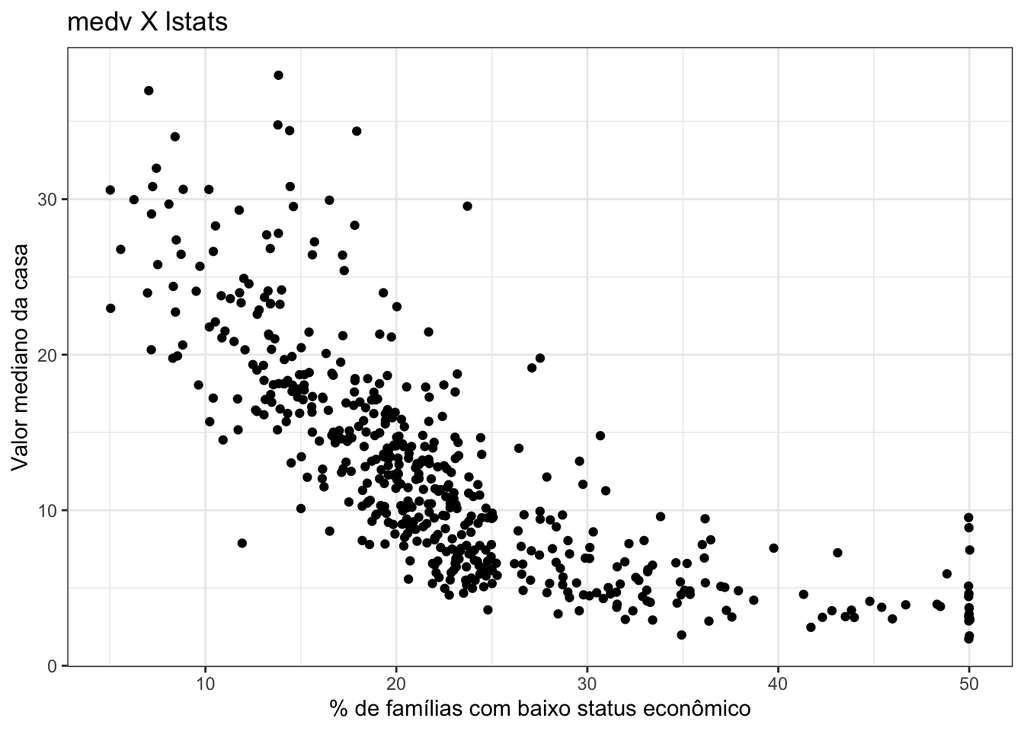

```r
# medv x lstats
Boston %>%
  ggplot()+
  geom_jitter(aes(x = medv, y = lstat))+
  theme_bw()+
  labs(title = "medv X lstats",
       y = "Valor mediano da casa",
       x = "% de famílias com baixo status econômico")
```

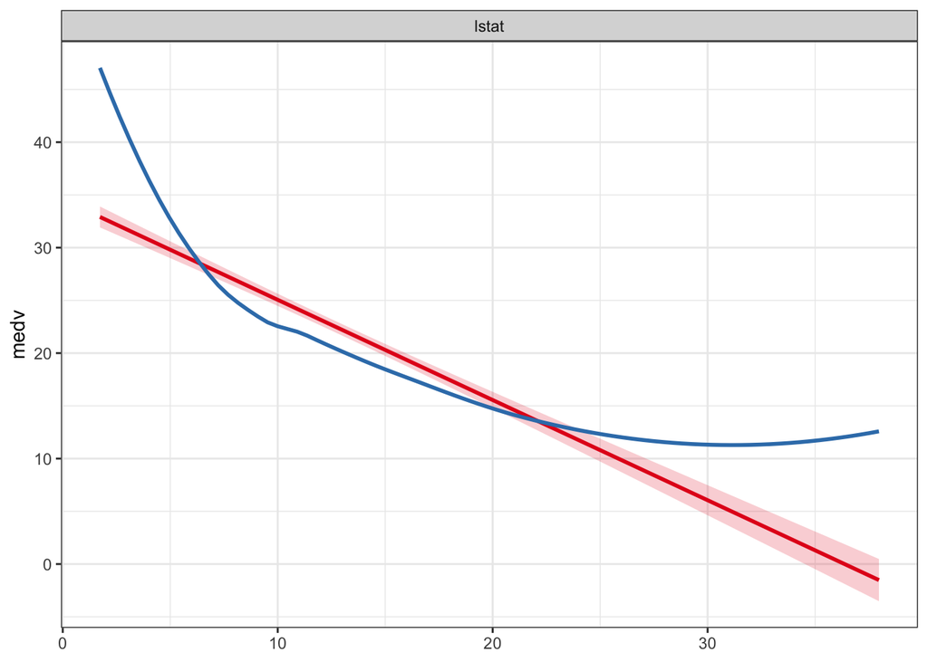

```r
# plotando mod1
plot_model(mod1)+
  theme_bw()
```

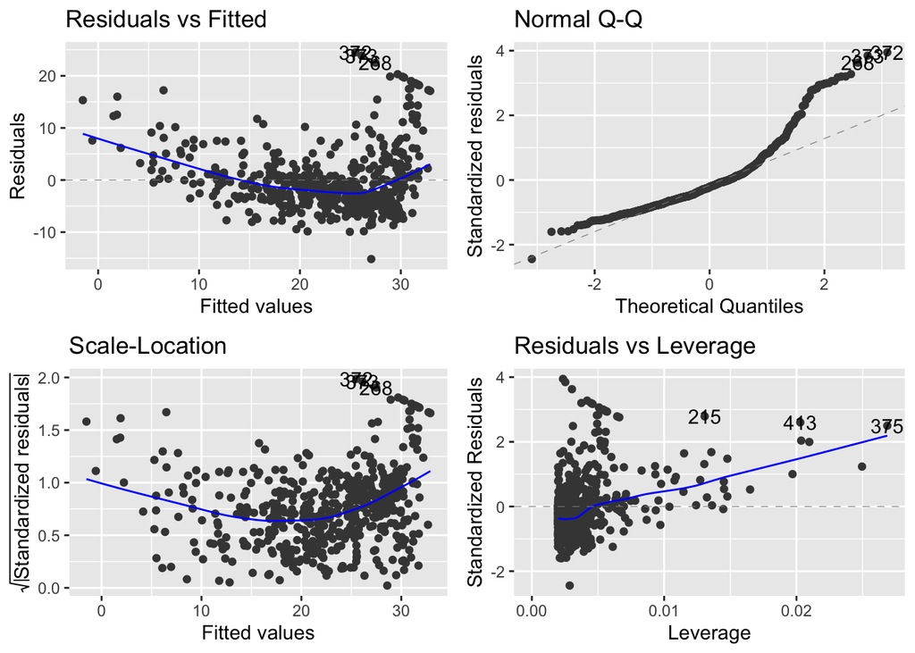

```r
# Diagnósticos
autoplot(mod1)
```

Agora, para a regressão múltipla (mais coeficientes), gera-se o modelo 2, **mod2**, e o **mod3**, onde todas as 13 variáveis serão incluídas:

```r
mod2 <- lm(medv ~ lstat + age, data = Boston)
summary(mod2)
```

```
##
## Call:
## lm(formula = medv ~ lstat + age, data = Boston)
##
## Residuals:
##     Min      1Q  Median      3Q     Max
## -15.981  -3.978  -1.283   1.968  23.158
##
## Coefficients:
##             Estimate Std. Error t value             Pr(>|t|)
## (Intercept) 33.22276    0.73085  45.458 < 0.0000000000000002 ***
## lstat       -1.03207    0.04819 -21.416 < 0.0000000000000002 ***
## age          0.03454    0.01223   2.826              0.00491 **
## ---
## Signif. codes:  0 '***' 0.001 '**' 0.01 '*' 0.05 '.' 0.1 ' ' 1
##
## Residual standard error: 6.173 on 503 degrees of freedom
## Multiple R-squared:  0.5513, Adjusted R-squared:  0.5495
## F-statistic:   309 on 2 and 503 DF,  p-value: < 0.00000000000000022
```

```r
mod3 <- lm(medv ~., data = Boston)
summary(mod3)
```

```
##
## Call:
## lm(formula = medv ~ ., data = Boston)
##
## Residuals:
##     Min      1Q  Median      3Q     Max
## -15.595  -2.730  -0.518   1.777  26.199
##
## Coefficients:
##                Estimate  Std. Error t value             Pr(>|t|)
## (Intercept)  36.4594884   5.1034588   7.144    0.000000000003283 ***
## crim         -0.1080114   0.0328650  -3.287             0.001087 **
## zn            0.0464205   0.0137275   3.382             0.000778 ***
## indus         0.0205586   0.0614957   0.334             0.738288
## chas          2.6867338   0.8615798   3.118             0.001925 **
## nox         -17.7666112   3.8197437  -4.651    0.000004245643808 ***
## rm            3.8098652   0.4179253   9.116 < 0.0000000000000002 ***
## age           0.0006922   0.0132098   0.052             0.958229
## dis          -1.4755668   0.1994547  -7.398    0.000000000000601 ***
## rad           0.3060495   0.0663464   4.613    0.000005070529023 ***
## tax          -0.0123346   0.0037605  -3.280             0.001112 **
## ptratio      -0.9527472   0.1308268  -7.283    0.000000000001309 ***
## black         0.0093117   0.0026860   3.467             0.000573 ***
## lstat        -0.5247584   0.0507153 -10.347 < 0.0000000000000002 ***
## ---
## Signif. codes:  0 '***' 0.001 '**' 0.01 '*' 0.05 '.' 0.1 ' ' 1
##
## Residual standard error: 4.745 on 492 degrees of freedom
## Multiple R-squared:  0.7406, Adjusted R-squared:  0.7338
## F-statistic: 108.1 on 13 and 492 DF,  p-value: < 0.00000000000000022
```

```r
vif(mod3)
```

```
##     crim       zn    indus     chas      nox       rm      age      dis
## 1.792192 2.298758 3.991596 1.073995 4.393720 1.933744 3.100826 3.955945
##      rad      tax  ptratio    black    lstat
## 7.484496 9.008554 1.799084 1.348521 2.941491
```

```r
mod3 <- update(mod3,~.-age)
```

Fazendo transformações não-lineares e utilizando **anova** para ver qual o melhor modelo:

```r
mod4 <- lm(medv ~ lstat +I(lstat^2))
summary(mod4)
```

```
##
## Call:
## lm(formula = medv ~ lstat + I(lstat^2))
##
## Residuals:
##      Min       1Q   Median       3Q      Max
## -15.2834  -3.8313  -0.5295   2.3095  25.4148
##
## Coefficients:
##              Estimate Std. Error t value            Pr(>|t|)
## (Intercept) 42.862007   0.872084   49.15 <0.0000000000000002 ***
## lstat       -2.332821   0.123803  -18.84 <0.0000000000000002 ***
## I(lstat^2)   0.043547   0.003745   11.63 <0.0000000000000002 ***
## ---
## Signif. codes:  0 '***' 0.001 '**' 0.01 '*' 0.05 '.' 0.1 ' ' 1
##
## Residual standard error: 5.524 on 503 degrees of freedom
## Multiple R-squared:  0.6407, Adjusted R-squared:  0.6393
## F-statistic: 448.5 on 2 and 503 DF,  p-value: < 0.00000000000000022
```

```r
anova(mod1, mod4)
```

```
## Analysis of Variance Table
##
## Model 1: medv ~ lstat
## Model 2: medv ~ lstat + I(lstat^2)
##   Res.Df   RSS Df Sum of Sq     F                Pr(>F)
## 1    504 19472
## 2    503 15347  1    4125.1 135.2 < 0.00000000000000022 ***
## ---
## Signif. codes:  0 '***' 0.001 '**' 0.01 '*' 0.05 '.' 0.1 ' ' 1
```

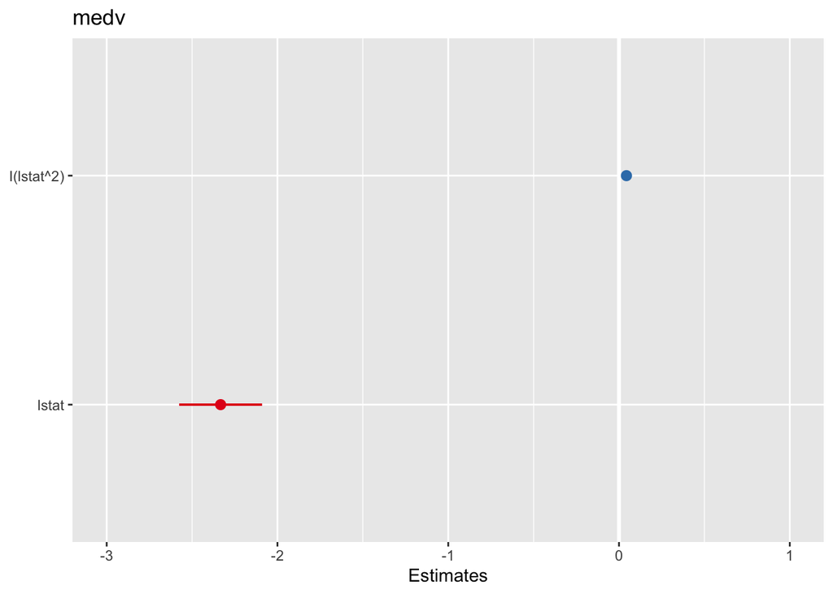

```r
plot_model(mod4)
```

# Exercícios

### Aplicados

8. Usando o banco **Auto**:

```r
ex8mod <- lm(mpg ~ horsepower, data = Auto)
summary(ex8mod)
```

```
##
## Call:
## lm(formula = mpg ~ horsepower, data = Auto)
##
## Residuals:
##      Min       1Q   Median       3Q      Max
## -13.5710  -3.2592  -0.3435   2.7630  16.9240
##
## Coefficients:
##              Estimate Std. Error t value            Pr(>|t|)
## (Intercept) 39.935861   0.717499   55.66 <0.0000000000000002 ***
## horsepower  -0.157845   0.006446  -24.49 <0.0000000000000002 ***
## ---
## Signif. codes:  0 '***' 0.001 '**' 0.01 '*' 0.05 '.' 0.1 ' ' 1
##
## Residual standard error: 4.906 on 390 degrees of freedom
## Multiple R-squared:  0.6059, Adjusted R-squared:  0.6049
## F-statistic: 599.7 on 1 and 390 DF,  p-value: < 0.00000000000000022
```

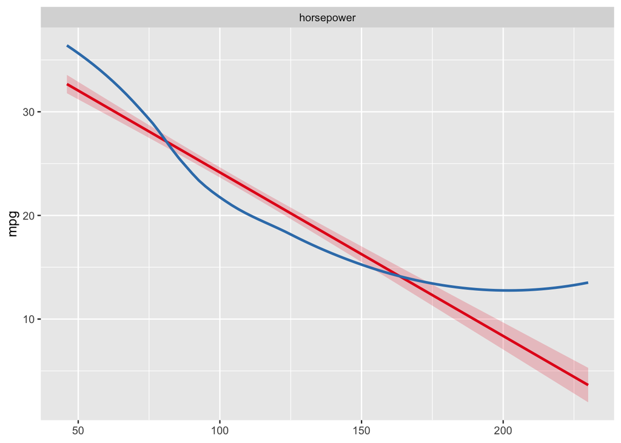

```r
plot_model(ex8mod)
```

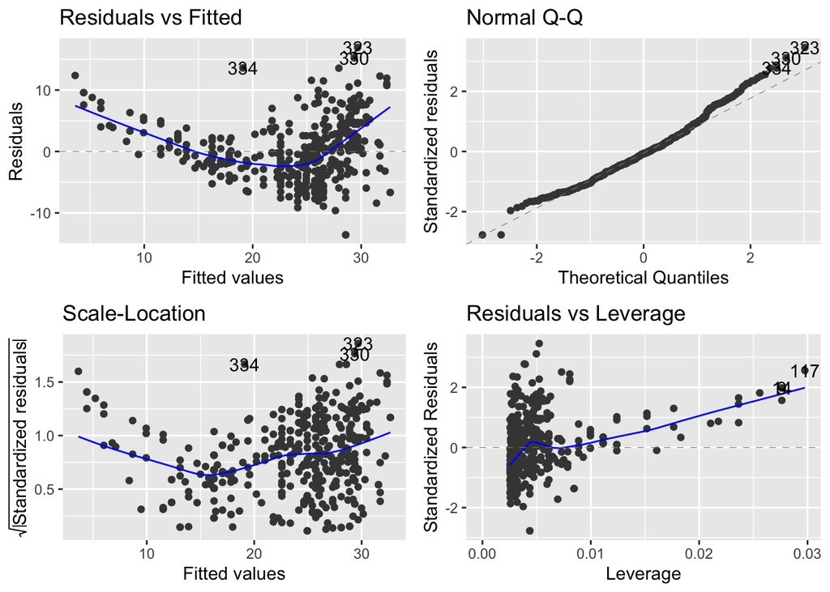

```r
autoplot(ex8mod)
```

```r
predict(ex8mod, data.frame(horsepower=c(98)), interval="confidence")
```

```
##        fit      lwr      upr
## 1 24.46708 23.97308 24.96108
```

```r
predict(ex8mod, data.frame(horsepower=c(98)), interval="predict")
```

```
##        fit     lwr      upr
## 1 24.46708 14.8094 34.12476
```

1. Sobre a regressão:
1. sim, há
2. forte, pois há um p-valor altamente significativo (menor que 0.001, virtualmente 0), e o $R^2$ é de 0.60
3. *horsepower* possui coeficiente negativo ($-0.15$), logo, o aumento de uma unidade em *horsepower* diminui em 0.15 *mpg*
4. $24.46$
2. plotado acima
3. há o problema de não-linearidade (plot de resíduos vs fitted)
9. Ainda sobre o banco **auto**:

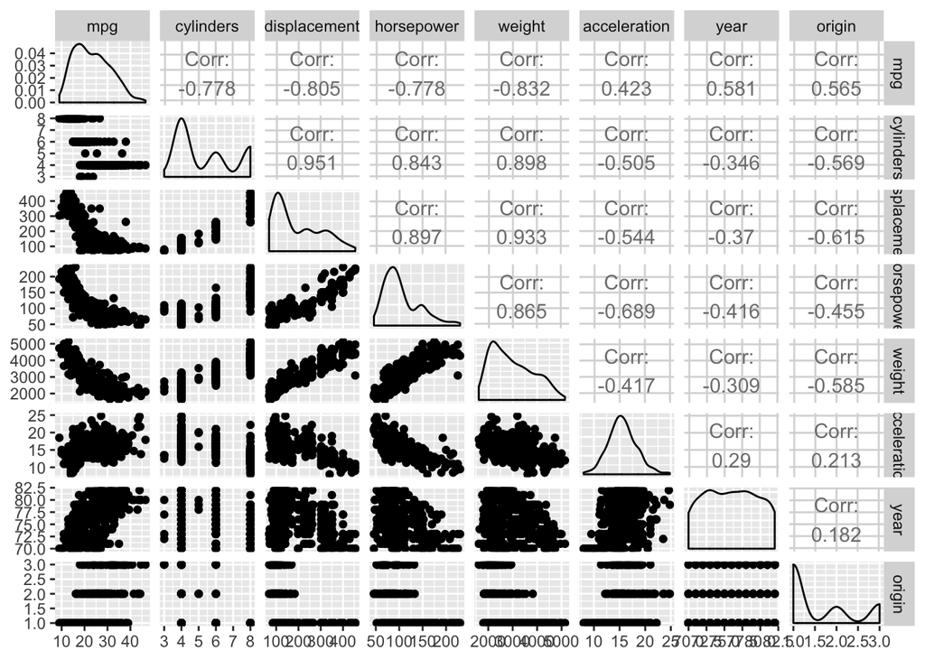

```r
# Matriz de correlação
Auto %>%
  select(-name) %>%
  ggpairs(.)
```

```r
# Correlações sem name
Auto %>%
  select(-name) %>%
  cor()
```

```
##                     mpg  cylinders displacement horsepower     weight
## mpg           1.0000000 -0.7776175   -0.8051269 -0.7784268 -0.8322442
## cylinders    -0.7776175  1.0000000    0.9508233  0.8429834  0.8975273
## displacement -0.8051269  0.9508233    1.0000000  0.8972570  0.9329944
## horsepower   -0.7784268  0.8429834    0.8972570  1.0000000  0.8645377
## weight       -0.8322442  0.8975273    0.9329944  0.8645377  1.0000000
## acceleration  0.4233285 -0.5046834   -0.5438005 -0.6891955 -0.4168392
## year          0.5805410 -0.3456474   -0.3698552 -0.4163615 -0.3091199
## origin        0.5652088 -0.5689316   -0.6145351 -0.4551715 -0.5850054
##              acceleration       year     origin
## mpg             0.4233285  0.5805410  0.5652088
## cylinders      -0.5046834 -0.3456474 -0.5689316
## displacement   -0.5438005 -0.3698552 -0.6145351
## horsepower     -0.6891955 -0.4163615 -0.4551715
## weight         -0.4168392 -0.3091199 -0.5850054
## acceleration    1.0000000  0.2903161  0.2127458
## year            0.2903161  1.0000000  0.1815277
## origin          0.2127458  0.1815277  1.0000000
```

```r
# modelo com todas as variáveis menos nome
ex9mod1 <- lm(mpg ~.-name, data = Auto)
summary(ex9mod1)
```

```
##
## Call:
## lm(formula = mpg ~ . - name, data = Auto)
##
## Residuals:
##     Min      1Q  Median      3Q     Max
## -9.5903 -2.1565 -0.1169  1.8690 13.0604
##
## Coefficients:
##                Estimate Std. Error t value             Pr(>|t|)
## (Intercept)  -17.218435   4.644294  -3.707              0.00024 ***
## cylinders     -0.493376   0.323282  -1.526              0.12780
## displacement   0.019896   0.007515   2.647              0.00844 **
## horsepower    -0.016951   0.013787  -1.230              0.21963
## weight        -0.006474   0.000652  -9.929 < 0.0000000000000002 ***
## acceleration   0.080576   0.098845   0.815              0.41548
## year           0.750773   0.050973  14.729 < 0.0000000000000002 ***
## origin         1.426141   0.278136   5.127          0.000000467 ***
## ---
## Signif. codes:  0 '***' 0.001 '**' 0.01 '*' 0.05 '.' 0.1 ' ' 1
##
## Residual standard error: 3.328 on 384 degrees of freedom
## Multiple R-squared:  0.8215, Adjusted R-squared:  0.8182
## F-statistic: 252.4 on 7 and 384 DF,  p-value: < 0.00000000000000022
```

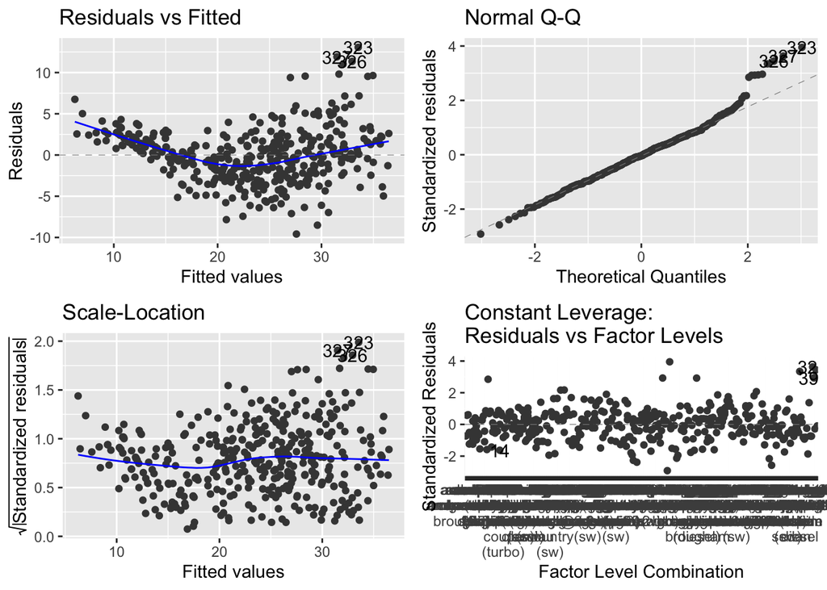

```r
# diagnósticos
autoplot(ex9mod1)
```

```r
# modelo com interações
ex9mod2 <-  lm(mpg ~ . * . -name*.+.-name, data = Auto)
summary(ex9mod2)
```

```
##
## Call:
## lm(formula = mpg ~ . * . - name * . + . - name, data = Auto)
##
## Residuals:
##     Min      1Q  Median      3Q     Max
## -7.6303 -1.4481  0.0596  1.2739 11.1386
##
## Coefficients:
##                               Estimate   Std. Error t value Pr(>|t|)
## (Intercept)                35.47888748  53.13578860   0.668  0.50475
## cylinders                   6.98857616   8.24797077   0.847  0.39738
## displacement               -0.47853869   0.18935343  -2.527  0.01192 *
## horsepower                  0.50343394   0.34699939   1.451  0.14769
## weight                      0.00413289   0.01759419   0.235  0.81442
## acceleration               -5.85917321   2.17362119  -2.696  0.00735 **
## year                        0.69743028   0.60967032   1.144  0.25340
## origin                    -20.89557040   7.09709051  -2.944  0.00345 **
## cylinders:displacement     -0.00338326   0.00645510  -0.524  0.60051
## cylinders:horsepower        0.01161333   0.02419810   0.480  0.63157
## cylinders:weight            0.00035746   0.00089549   0.399  0.69000
## cylinders:acceleration      0.27787199   0.16642155   1.670  0.09584 .
## cylinders:year             -0.17412586   0.09714126  -1.793  0.07389 .
## cylinders:origin            0.40216822   0.49262243   0.816  0.41482
## displacement:horsepower    -0.00008491   0.00028846  -0.294  0.76867
## displacement:weight         0.00002472   0.00001470   1.682  0.09342 .
## displacement:acceleration  -0.00347900   0.00334174  -1.041  0.29853
## displacement:year           0.00593380   0.00239072   2.482  0.01352 *
## displacement:origin         0.02398113   0.01946528   1.232  0.21875
## horsepower:weight          -0.00001968   0.00002924  -0.673  0.50124
## horsepower:acceleration    -0.00721274   0.00371945  -1.939  0.05325 .
## horsepower:year            -0.00583751   0.00393847  -1.482  0.13916
## horsepower:origin           0.00223251   0.02930144   0.076  0.93931
## weight:acceleration         0.00023462   0.00022886   1.025  0.30596
## weight:year                -0.00022452   0.00021268  -1.056  0.29182
## weight:origin              -0.00057885   0.00159117  -0.364  0.71623
## acceleration:year           0.05562151   0.02558175   2.174  0.03033 *
## acceleration:origin         0.45831610   0.15665969   2.926  0.00365 **
## year:origin                 0.13925702   0.07398950   1.882  0.06062 .
## ---
## Signif. codes:  0 '***' 0.001 '**' 0.01 '*' 0.05 '.' 0.1 ' ' 1
##
## Residual standard error: 2.695 on 363 degrees of freedom
## Multiple R-squared:  0.8893, Adjusted R-squared:  0.8808
## F-statistic: 104.2 on 28 and 363 DF,  p-value: < 0.00000000000000022
```

```r
ex9mod3 <- lm(mpg~ -name +displacement*weight + displacement*year + horsepower*acceleration, data = Auto)
summary(ex9mod3)
```

```
##
## Call:
## lm(formula = mpg ~ -name + displacement * weight + displacement *
##     year + horsepower * acceleration, data = Auto)
##
## Residuals:
##    Min     1Q Median     3Q    Max
## -8.712 -1.668  0.038  1.385 13.040
##
## Coefficients:
##                              Estimate    Std. Error t value
## (Intercept)             -37.081883362   7.293267880  -5.084
## displacement              0.087940312   0.038633294   2.276
## weight                   -0.008655555   0.000837045 -10.341
## year                      1.124216290   0.091557552  12.279
## horsepower                0.016858610   0.024916837   0.677
## acceleration              0.411283804   0.155595224   2.643
## displacement:weight       0.000019103   0.000002232   8.559
## displacement:year        -0.002052799   0.000485401  -4.229
## horsepower:acceleration  -0.004497905   0.001773523  -2.536
##                                     Pr(>|t|)
## (Intercept)             0.000000578201413633 ***
## displacement                         0.02338 *
## weight                  < 0.0000000000000002 ***
## year                    < 0.0000000000000002 ***
## horsepower                           0.49907
## acceleration                         0.00855 **
## displacement:weight     0.000000000000000279 ***
## displacement:year       0.000029382035978029 ***
## horsepower:acceleration              0.01160 *
## ---
## Signif. codes:  0 '***' 0.001 '**' 0.01 '*' 0.05 '.' 0.1 ' ' 1
##
## Residual standard error: 2.854 on 383 degrees of freedom
## Multiple R-squared:  0.8691, Adjusted R-squared:  0.8663
## F-statistic: 317.7 on 8 and 383 DF,  p-value: < 0.00000000000000022
```

```r
# modelo com transformação
ex9mod4 <-  lm(mpg ~ horsepower + I(log(displacement)), data = Auto)
summary(ex9mod4)
```

```
##
## Call:
## lm(formula = mpg ~ horsepower + I(log(displacement)), data = Auto)
##
## Residuals:
##      Min       1Q   Median       3Q      Max
## -14.0107  -2.5841  -0.4108   2.0452  17.4288
##
## Coefficients:
##                      Estimate Std. Error t value             Pr(>|t|)
## (Intercept)          74.45261    3.08888  24.103 < 0.0000000000000002 ***
## horsepower           -0.05296    0.01076  -4.923           0.00000126 ***
## I(log(displacement)) -8.86789    0.77733 -11.408 < 0.0000000000000002 ***
## ---
## Signif. codes:  0 '***' 0.001 '**' 0.01 '*' 0.05 '.' 0.1 ' ' 1
##
## Residual standard error: 4.252 on 389 degrees of freedom
## Multiple R-squared:  0.7047, Adjusted R-squared:  0.7032
## F-statistic: 464.2 on 2 and 389 DF,  p-value: < 0.00000000000000022
```

a e b) acima c) 1. há relação, com F-statistics maior que 1 2. forte (p-valor baixo em displacement, weight, year e origin) 3. year mostra que a cada unidade adiciona em ano, mpg aumenta em 0.75 d) outliers nas obs 326, 327e 323, e high leverage em 32, 39 e 14. e) vários significantes f) fazendo log de displacement percebemos significância

10. Agora, usando o banco Carseats:

```r
ex10mod1 <- lm(Sales ~ Urban + Price + US, data = Carseats)
summary(ex10mod1)
```

```
##
## Call:
## lm(formula = Sales ~ Urban + Price + US, data = Carseats)
##
## Residuals:
##     Min      1Q  Median      3Q     Max
## -6.9206 -1.6220 -0.0564  1.5786  7.0581
##
## Coefficients:
##              Estimate Std. Error t value             Pr(>|t|)
## (Intercept) 13.043469   0.651012  20.036 < 0.0000000000000002 ***
## UrbanYes    -0.021916   0.271650  -0.081                0.936
## Price       -0.054459   0.005242 -10.389 < 0.0000000000000002 ***
## USYes        1.200573   0.259042   4.635           0.00000486 ***
## ---
## Signif. codes:  0 '***' 0.001 '**' 0.01 '*' 0.05 '.' 0.1 ' ' 1
##
## Residual standard error: 2.472 on 396 degrees of freedom
## Multiple R-squared:  0.2393, Adjusted R-squared:  0.2335
## F-statistic: 41.52 on 3 and 396 DF,  p-value: < 0.00000000000000022
```

```r
ex10mod2 <- lm(Sales ~ Price + US, data = Carseats)
summary(ex10mod2)
```

```
##
## Call:
## lm(formula = Sales ~ Price + US, data = Carseats)
##
## Residuals:
##     Min      1Q  Median      3Q     Max
## -6.9269 -1.6286 -0.0574  1.5766  7.0515
##
## Coefficients:
##             Estimate Std. Error t value             Pr(>|t|)
## (Intercept) 13.03079    0.63098  20.652 < 0.0000000000000002 ***
## Price       -0.05448    0.00523 -10.416 < 0.0000000000000002 ***
## USYes        1.19964    0.25846   4.641           0.00000471 ***
## ---
## Signif. codes:  0 '***' 0.001 '**' 0.01 '*' 0.05 '.' 0.1 ' ' 1
##
## Residual standard error: 2.469 on 397 degrees of freedom
## Multiple R-squared:  0.2393, Adjusted R-squared:  0.2354
## F-statistic: 62.43 on 2 and 397 DF,  p-value: < 0.00000000000000022
```

```r
stargazer::stargazer(ex10mod1, ex10mod2, type = "text")
```

```
##
##                                   Dependent variable:
##                                          Sales
##                               (1)                     (2)
## UrbanYes                    -0.022
##                             (0.272)
## Price                      -0.054***               -0.054***
##                             (0.005)                 (0.005)
## USYes                      1.201***                1.200***
##                             (0.259)                 (0.258)
## Constant                   13.043***               13.031***
##                             (0.651)                 (0.631)
## Observations                  400                     400
## R2                           0.239                   0.239
## Adjusted R2                  0.234                   0.235
## Residual Std. Error    2.472 (df = 396)        2.469 (df = 397)
## F Statistic         41.519*** (df = 3; 396) 62.431*** (df = 2; 397)
## Note:                                   *p<0.1; **p<0.05; ***p<0.01
```

```r
anova(ex10mod1, ex10mod2)
```

```
## Analysis of Variance Table
##
## Model 1: Sales ~ Urban + Price + US
## Model 2: Sales ~ Price + US
##   Res.Df    RSS Df Sum of Sq      F Pr(>F)
## 1    396 2420.8
## 2    397 2420.9 -1  -0.03979 0.0065 0.9357
```

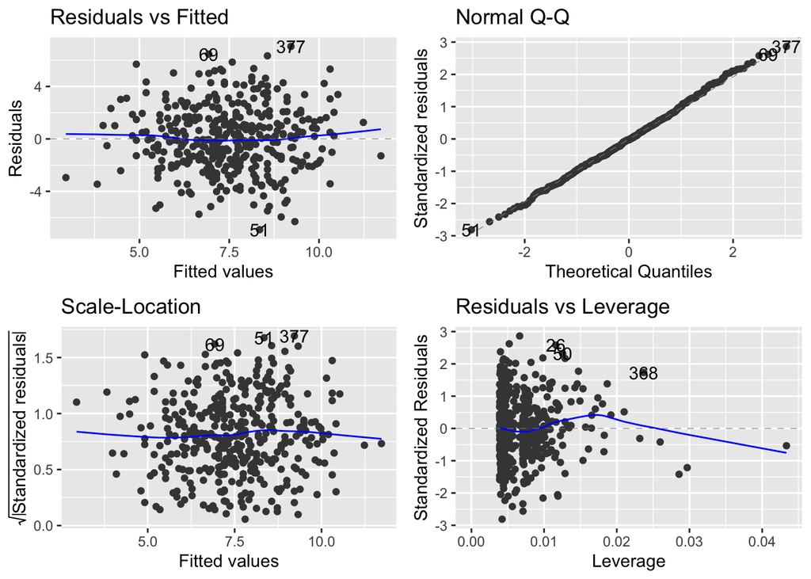

```r
autoplot(ex10mod2)
```

```r
confint(ex10mod2)
```

```
##                   2.5 %      97.5 %
## (Intercept) 11.79032020 14.27126531
## Price       -0.06475984 -0.04419543
## USYes        0.69151957  1.70776632
```

1. acima
2. - o fato de ser em localidades urbanas não é significante, logo o coeficiente não é interpretado
   - a cada unidade adicionada em preço, diminui-se 0.05 em vendas
   - o fato de ser nos EUA aumenta em 1.20 as vendas
3. $Sales = 13.04 - 0.02 \times UrbanYes - 0.05 \times Price + 1.20 \times USYes$
4. Pode-se rejeitar a $H_0$ para Price e USYes dado o p-valor baíxisimo e altamente significante
5. acima
6. o R2 Ajustado do segundo modelo é maior que do primeiro, e o RSE do segundo é menor que o do primeiro, logo, o segundo é melhor (ligeiramente)
7. acima
8. Sim, high-leverage